# Eliciting Probability Distributions with SHELF

Jeremy Oakley

2016-06-29

It is assumed that experts provide either probability or quantile judgements: the expert is either asked questions of the form, `What is your probability $P(X<=10)$?'' or,`Provide a value $x$ such that you think $P(X\le x)=0.5.$’’ Either way, we think of the expert as providing points on his/her cumulative distribution function.

Expert 1 states $P(X<30)=0.25, P(X<40)=0.5, P(X<50)=0.75$ Expert 2 states $P(X<20)=0.25, P(X<25)=0.5, P(X<35)=0.75$ Both experts state $0<X<100$

The values of the quantiles are arranged in a matrix, with one column per expert

```r
(v <- matrix(c(30, 40, 50, 20, 25, 35), 3, 2))
```

```
##      [,1] [,2]
## [1,]   30   20
## [2,]   40   25
## [3,]   50   35
```

(With one expert only, the values can be stored in a vector, as shown later.)

The probabilities should be arranged in matrix if they are different for the two experts, otherwise they are stored in a vector

```r
library(SHELF)
(v <- matrix(c(30, 40, 50, 20, 25, 35), 3, 2))
```

```
##      [,1] [,2]
## [1,]   30   20
## [2,]   40   25
## [3,]   50   35
```

```r
(p <- c(0.25, 0.5, 0.75))
```

```
## [1] 0.25 0.50 0.75
```

```r
library(SHELF)
myfit <- fitdist(vals = v, probs = p, lower = 0, upper = 100)
```

Plot the fitted distributions, including a linear pool

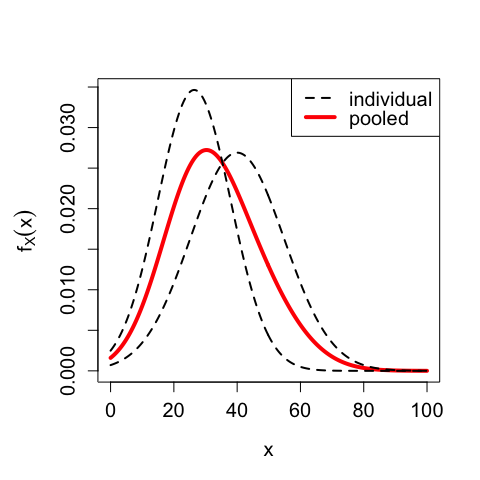

```r
plotfit(myfit, lp=T)
```

Now elicit a single ‘consensus’ distribution from the two experts Suppose they agree $P(X<25)=0.25, P(X<30)=0.5, P(X<40)=0.75$

```r
v <-c(25, 30, 40)
p <-c(0.25, 0.5, 0.75)
myfit <- fitdist(vals = v, probs = p, lower = 0, upper = 100)
```

Plot the fitted density, and report some feedback, such as the fitted 5th and 95th percentiles

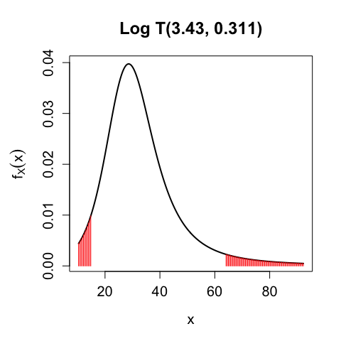

```r
plotfit(myfit, ql=0.05, qu=0.95)
```

```r
feedback(myfit, quantiles=c(0.05,0.95))
```

```
## $fitted.quantiles
##      Normal Student-t Gamma Log normal Log Student-t Beta
## 0.05   12.5      7.49  16.2       17.3          14.8 15.2
## 0.95   50.4     55.10  53.2       55.3          64.1 51.2
##
## $fitted.probabilities
##    elicited Normal Student-t Gamma Log normal Log Student-t  Beta
## 25     0.25  0.288     0.289 0.279      0.274         0.275 0.283
## 30     0.50  0.451     0.453 0.461      0.466         0.469 0.456
## 40     0.75  0.772     0.774 0.769      0.767         0.768 0.770
```